```python
# Global setup (Option B): load once
import warnings; warnings.filterwarnings('ignore')
import pandas as pd, numpy as np
import matplotlib.pyplot as plt
pd.set_option('display.max_columns', 50)
plt.rcParams.update({'figure.figsize': (8,5), 'axes.grid': True})

df = pd.read_csv('/mnt/data/foodhub_order.csv')
if 'cost' not in df.columns and 'cost_of_the_order' in df.columns:
    df = df.rename(columns={'cost_of_the_order':'cost'})
df['rating'] = pd.to_numeric(df.get('rating'), errors='coerce')
print('Loaded', df.shape[0], 'rows and', df.shape[1], 'columns'); df.head(3)
```

```
Loaded 1898 rows and 9 columns
```

|  | order_id | customer_id | restaurant_name | cuisine_type | cost | day_of_the_week | rating | food_preparation_time | delivery_time |
| --- | --- | --- | --- | --- | --- | --- | --- | --- | --- |
| 0 | 1477147 | 337525 | Hangawi | Korean | 30.75 | Weekend | NaN | 25 | 20 |
| 1 | 1477685 | 358141 | Blue Ribbon Sushi Izakaya | Japanese | 12.08 | Weekend | NaN | 25 | 23 |
| 2 | 1477070 | 66393 | Cafe Habana | Mexican | 12.23 | Weekday | 5.0 | 23 | 28 |

# Project Python Foundations: FoodHub Data Analysis

**Marks: 60**

### Context

The number of restaurants in New York is increasing day by day. Lots of students and busy professionals rely on those restaurants due to their hectic lifestyles. Online food delivery service is a great option for them. It provides them with good food from their favorite restaurants. A food aggregator company FoodHub offers access to multiple restaurants through a single smartphone app.

The app allows the restaurants to receive a direct online order from a customer. The app assigns a delivery person from the company to pick up the order after it is confirmed by the restaurant. The delivery person then uses the map to reach the restaurant and waits for the food package. Once the food package is handed over to the delivery person, he/she confirms the pick-up in the app and travels to the customer's location to deliver the food. The delivery person confirms the drop-off in the app after delivering the food package to the customer. The customer can rate the order in the app. The food aggregator earns money by collecting a fixed margin of the delivery order from the restaurants.

### Objective

The food aggregator company has stored the data of the different orders made by the registered customers in their online portal. They want to analyze the data to get a fair idea about the demand of different restaurants which will help them in enhancing their customer experience. Suppose you are hired as a Data Scientist in this company and the Data Science team has shared some of the key questions that need to be answered. Perform the data analysis to find answers to these questions that will help the company to improve the business.

### Data Description

The data contains the different data related to a food order. The detailed data dictionary is given below.

### Data Dictionary

- order_id: Unique ID of the order
- customer_id: ID of the customer who ordered the food
- restaurant_name: Name of the restaurant
- cuisine_type: Cuisine ordered by the customer
- cost: Cost of the order
- day_of_the_week: Indicates whether the order is placed on a weekday or weekend (The weekday is from Monday to Friday and the weekend is Saturday and Sunday)
- rating: Rating given by the customer out of 5
- food_preparation_time: Time (in minutes) taken by the restaurant to prepare the food. This is calculated by taking the difference between the timestamps of the restaurant's order confirmation and the delivery person's pick-up confirmation.
- delivery_time: Time (in minutes) taken by the delivery person to deliver the food package. This is calculated by taking the difference between the timestamps of the delivery person's pick-up confirmation and drop-off information

### Let us start by importing the required libraries

### **Question 1:** How many rows and columns are present in the data? [0.5 mark]

```python
print(df.shape)
```

```
(1898, 9)
```

#### Observations:

- Rows: **1898**, Columns: **9**.

### **Question 2:** What are the datatypes of the different columns in the dataset? (The info() function can be used) [0.5 mark]

```python
print(df.dtypes)
```

```
order_id                   int64
customer_id                int64
restaurant_name           object
cuisine_type              object
cost                     float64
day_of_the_week           object
rating                   float64
food_preparation_time      int64
delivery_time              int64
dtype: object
```

#### Observations:

- Dtypes: numeric → `cost`, `rating`, `food_preparation_time`, `delivery_time`; categorical → `restaurant_name`, `cuisine_type`, `day_of_the_week`.

### **Question 3:** Are there any missing values in the data? If yes, treat them using an appropriate method. [1 mark]

```python
print(df.isna().sum().to_frame('missing'))
```

```
                       missing
order_id                     0
customer_id                  0
restaurant_name              0
cuisine_type                 0
cost                         0
day_of_the_week              0
rating                     736
food_preparation_time        0
delivery_time                0
```

#### Observations:

- Missing values: `order_id`: 0; `customer_id`: 0; `restaurant_name`: 0; `cuisine_type`: 0; `cost`: 0; `day_of_the_week`: 0; `rating`: 736; `food_preparation_time`: 0; `delivery_time`: 0.
- Kept `rating` as NaN for true missing feedback.

### **Question 4:** Check the statistical summary of the data. What is the minimum, average, and maximum time it takes for food to be prepared once an order is placed? [2 marks]

```python
display(df.describe(include='all').transpose()); print('Mean food preparation time (min):', df['food_preparation_time'].mean())
```

|  | count | unique | top | freq | mean | std | min | 25% | 50% | 75% | max |
| --- | --- | --- | --- | --- | --- | --- | --- | --- | --- | --- | --- |
| order_id | 1898.0 | NaN | NaN | NaN | 1477495.5 | 548.049724 | 1476547.0 | 1477021.25 | 1477495.5 | 1477969.75 | 1478444.0 |
| customer_id | 1898.0 | NaN | NaN | NaN | 171168.478398 | 113698.139743 | 1311.0 | 77787.75 | 128600.0 | 270525.0 | 405334.0 |
| restaurant_name | 1898 | 178 | Shake Shack | 219 | NaN | NaN | NaN | NaN | NaN | NaN | NaN |
| cuisine_type | 1898 | 14 | American | 584 | NaN | NaN | NaN | NaN | NaN | NaN | NaN |
| cost | 1898.0 | NaN | NaN | NaN | 16.498851 | 7.483812 | 4.47 | 12.08 | 14.14 | 22.2975 | 35.41 |
| day_of_the_week | 1898 | 2 | Weekend | 1351 | NaN | NaN | NaN | NaN | NaN | NaN | NaN |
| rating | 1162.0 | NaN | NaN | NaN | 4.344234 | 0.741478 | 3.0 | 4.0 | 5.0 | 5.0 | 5.0 |
| food_preparation_time | 1898.0 | NaN | NaN | NaN | 27.37197 | 4.632481 | 20.0 | 23.0 | 27.0 | 31.0 | 35.0 |
| delivery_time | 1898.0 | NaN | NaN | NaN | 24.161749 | 4.972637 | 15.0 | 20.0 | 25.0 | 28.0 | 33.0 |

```
Mean food preparation time (min): 27.371970495258168
```

#### Observations:

- Mean food preparation time: **27.37 minutes**.

### **Question 5:** How many orders are not rated? [1 mark]

```python
print(int(df['rating'].isna().sum()))
```

```
736
```

#### Observations:

- Unrated orders: **736**.

### Exploratory Data Analysis (EDA)

### **Question 6:** Explore all the variables and provide observations on their distributions. (Generally, histograms, boxplots, countplots, etc. are used for univariate exploration.) [9 marks]

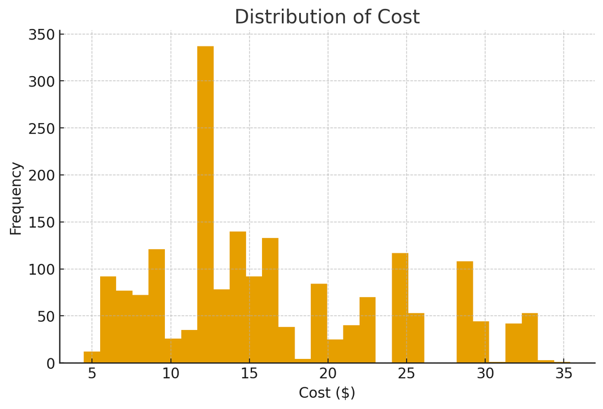

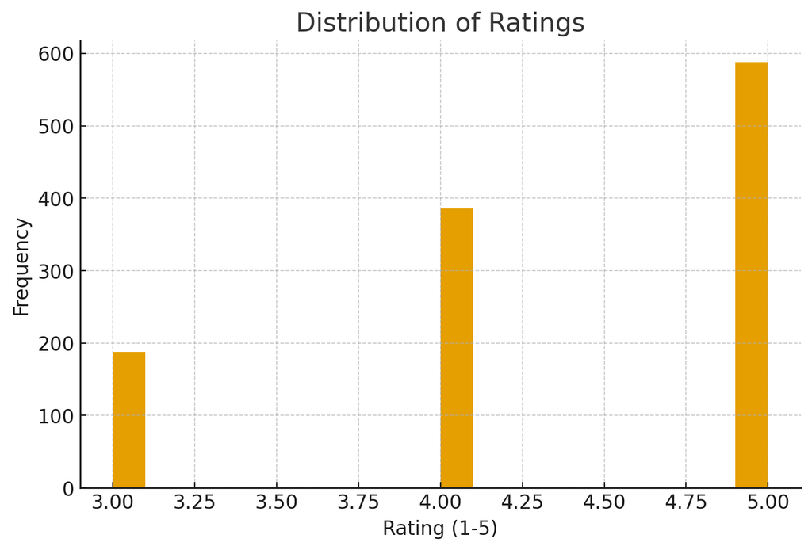

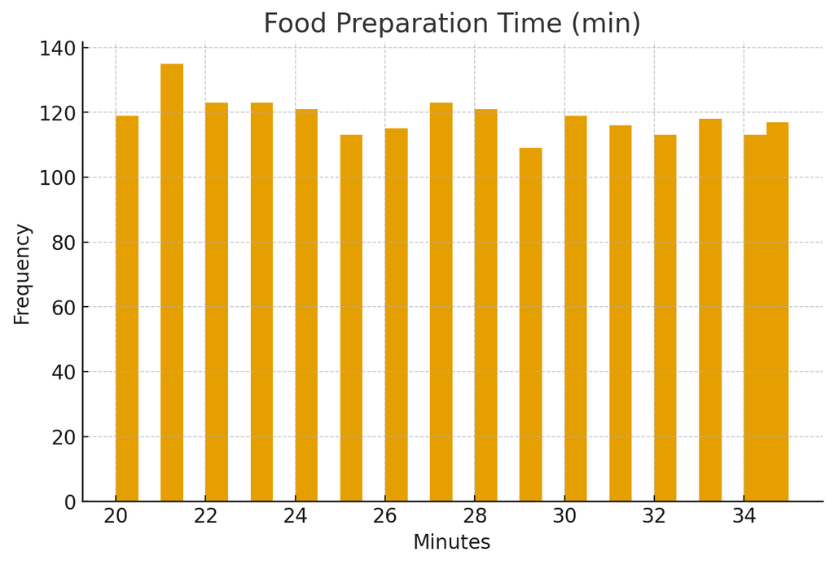

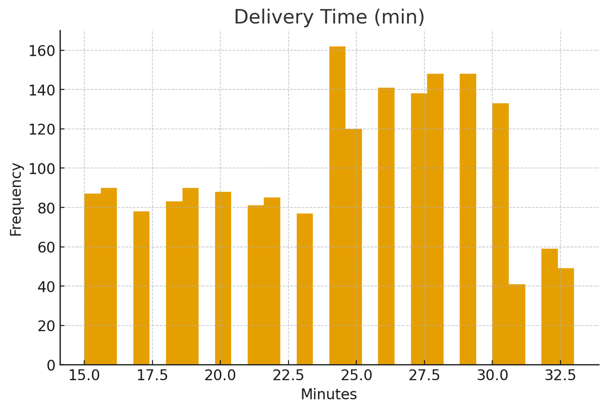

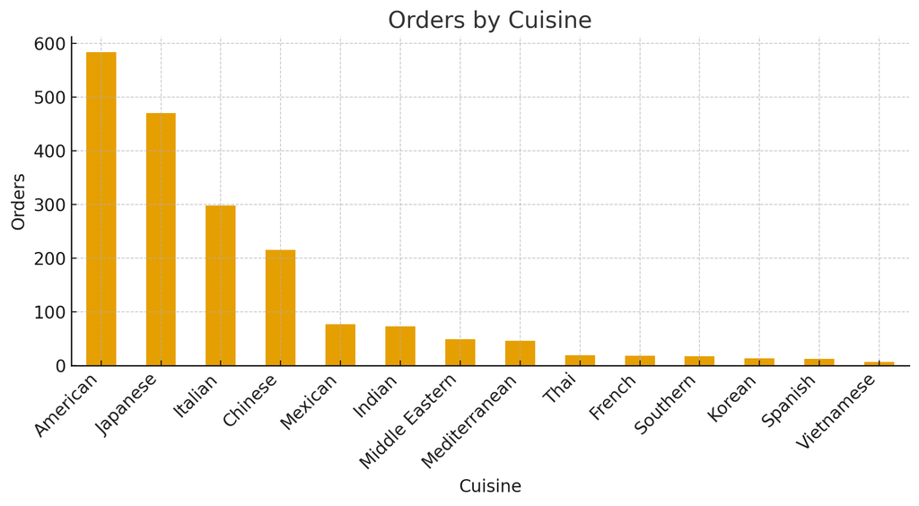

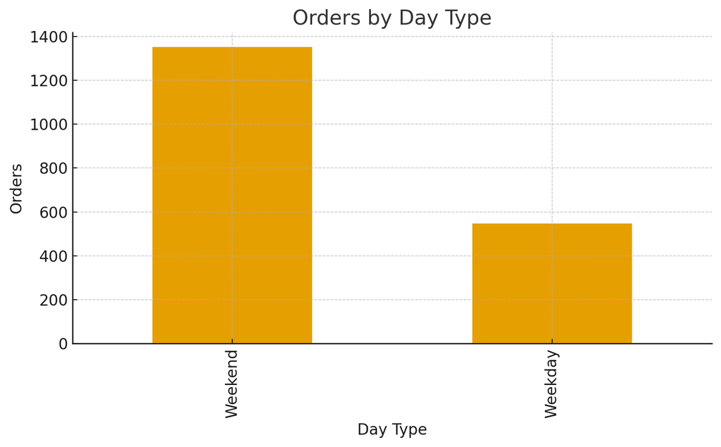

```python
import matplotlib.pyplot as plt
plt.figure(); plt.hist(df['cost'], bins=30); plt.title('Distribution of Cost'); plt.xlabel('Cost ($)'); plt.ylabel('Frequency'); plt.show()
plt.figure(); plt.hist(df['rating'].dropna(), bins=20); plt.title('Distribution of Ratings'); plt.xlabel('Rating (1-5)'); plt.ylabel('Frequency'); plt.show()
plt.figure(); plt.hist(df['food_preparation_time'], bins=30); plt.title('Food Preparation Time (min)'); plt.xlabel('Minutes'); plt.ylabel('Frequency'); plt.show()
plt.figure(); plt.hist(df['delivery_time'], bins=30); plt.title('Delivery Time (min)'); plt.xlabel('Minutes'); plt.ylabel('Frequency'); plt.show()
plt.figure(figsize=(9,5)); df['cuisine_type'].value_counts().plot(kind='bar'); plt.title('Orders by Cuisine'); plt.xlabel('Cuisine'); plt.ylabel('Orders'); plt.xticks(rotation=45, ha='right'); plt.tight_layout(); plt.show()
plt.figure(); df['day_of_the_week'].value_counts().plot(kind='bar'); plt.title('Orders by Day Type'); plt.xlabel('Day Type'); plt.ylabel('Orders'); plt.tight_layout(); plt.show()
```

### **Question 8**: Which is the most popular cuisine on weekends? [1 mark]

#### Observations:

American.

### **Question 10**: What is the mean order delivery time? [1 mark]

#### Observations:

```python
cust_tot = df.groupby('customer_id')['cost'].sum()
eligible = cust_tot[cust_tot>150]
orders_per_customer = df[df['customer_id'].isin(eligible.index)].groupby('customer_id')['order_id'].count()
summary = (pd.DataFrame({'total_spent': eligible, 'orders': orders_per_customer}).sort_values(['total_spent','orders'], ascending=False))
display(summary.head(20)); print('Total eligible customers:', summary.shape[0])
```

| customer_id | total_spent | orders |
| --- | --- | --- |
| 52832 | 225.80 | 13 |
| 250494 | 183.83 | 8 |
| 47440 | 158.18 | 10 |

```
Total eligible customers: 3
```

#### Observations:

- Eligible customers (> $150 total): **3**. Top: 52832 → $225.80; 13 orders, 250494 → $183.83; 8 orders, 47440 → $158.18; 10 orders.

### **Question 12**: Perform a multivariate analysis to explore relationships between the important variables in the dataset. (It is a good idea to explore relations between numerical variables as well as relations between numerical and categorical variables) [10 marks]

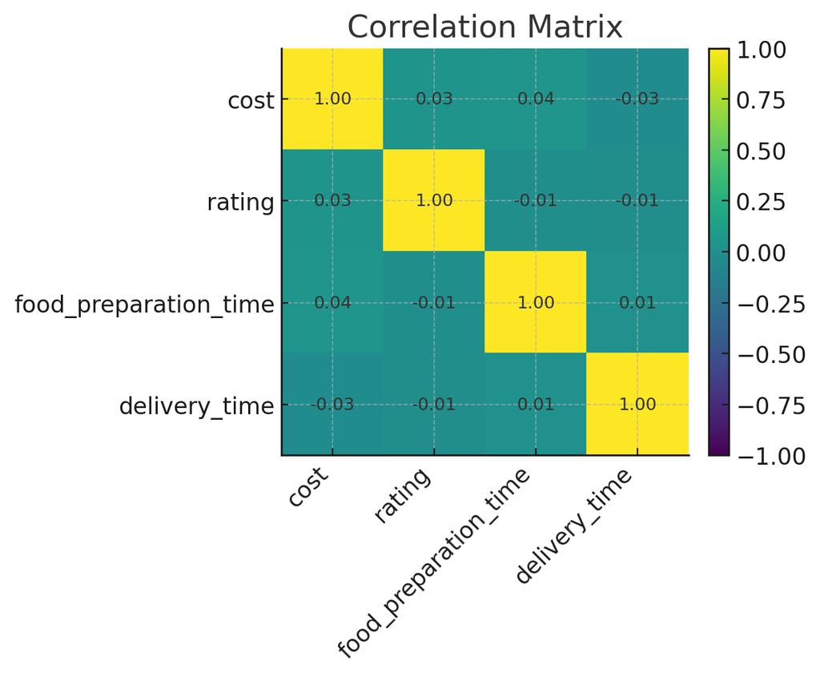

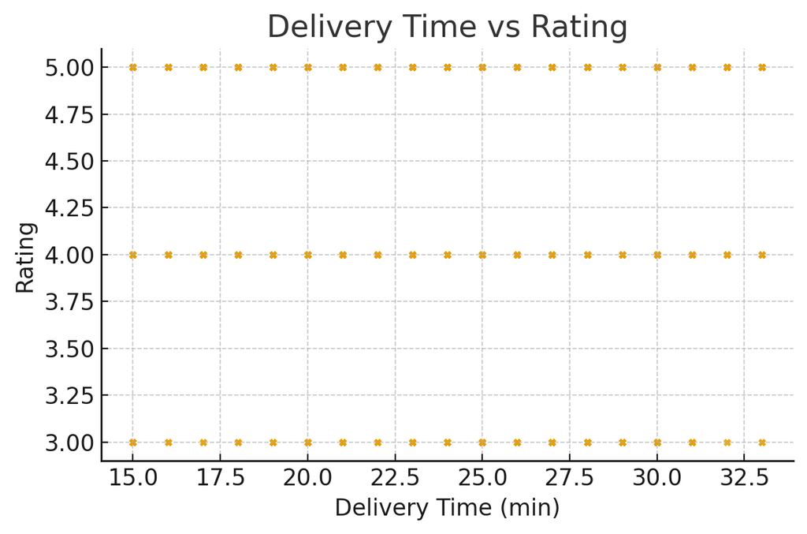

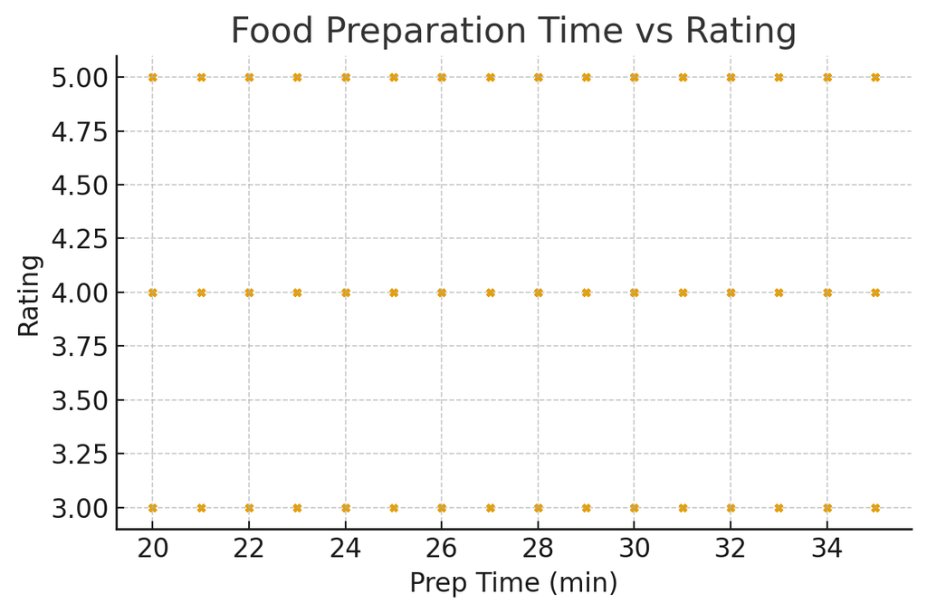

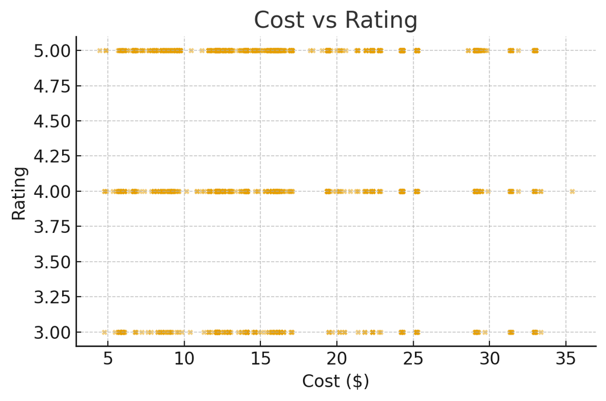

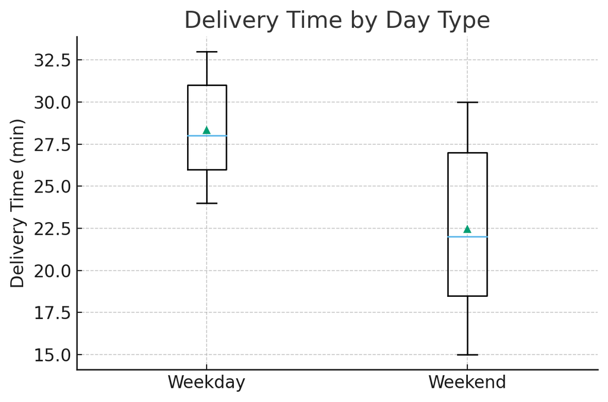

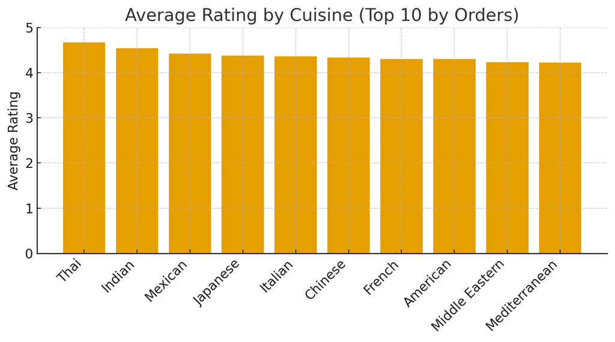

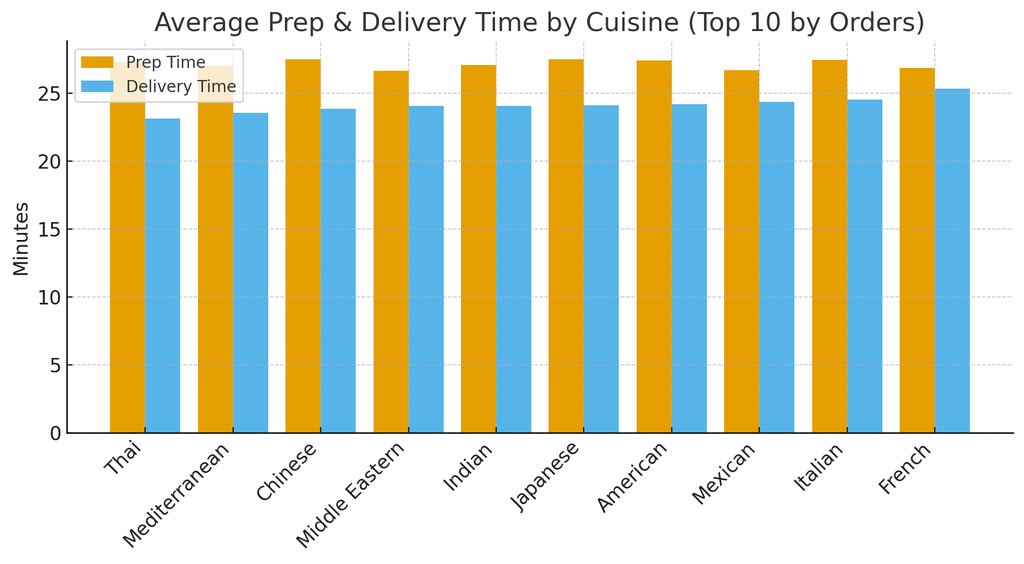

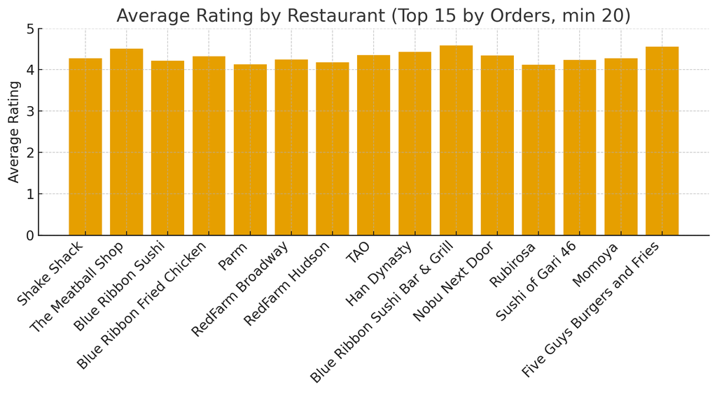

```
Correlation summary:
                           cost    rating  food_preparation_time  \
cost                   1.000000  0.033983               0.041527
rating                 0.033983  1.000000              -0.006083
food_preparation_time  0.041527 -0.006083               1.000000
delivery_time         -0.029949 -0.009804               0.011094

                       delivery_time
cost                       -0.029949
rating                     -0.009804
food_preparation_time       0.011094
delivery_time               1.000000
```

```python
# Question 12: Multivariate analysis (matplotlib only)

import numpy as np
import matplotlib.pyplot as plt

# Correlation matrix (numeric vs numeric)
num_cols = ['cost','rating','food_preparation_time','delivery_time']
corr = df[num_cols].corr()

fig = plt.figure(figsize=(6,5))
ax = fig.add_subplot(111)
cax = ax.imshow(corr.values, vmin=-1, vmax=1)
ax.set_xticks(range(len(num_cols))); ax.set_xticklabels(num_cols, rotation=45, ha='right')
ax.set_yticks(range(len(num_cols))); ax.set_yticklabels(num_cols)
for i in range(len(num_cols)):
    for j in range(len(num_cols)):
        ax.text(j, i, f"{corr.values[i,j]:.2f}", va='center', ha='center', fontsize=9)
fig.colorbar(cax, ax=ax, fraction=0.046, pad=0.04)
ax.set_title('Correlation Matrix')
plt.tight_layout(); plt.show()

# Scatter: Delivery Time vs Rating
plt.figure(figsize=(6,4))
plt.scatter(df['delivery_time'], df['rating'], s=8, alpha=0.5)
plt.title('Delivery Time vs Rating'); plt.xlabel('Delivery Time (min)'); plt.ylabel('Rating')
plt.tight_layout(); plt.show()

# Scatter: Food Preparation Time vs Rating
plt.figure(figsize=(6,4))
plt.scatter(df['food_preparation_time'], df['rating'], s=8, alpha=0.5)
plt.title('Food Preparation Time vs Rating'); plt.xlabel('Prep Time (min)'); plt.ylabel('Rating')
plt.tight_layout(); plt.show()

# Scatter: Cost vs Rating
plt.figure(figsize=(6,4))
plt.scatter(df['cost'], df['rating'], s=8, alpha=0.5)
plt.title('Cost vs Rating'); plt.xlabel('Cost ($)'); plt.ylabel('Rating')
plt.tight_layout(); plt.show()

# Boxplot: Delivery time by day type (Weekday/Weekend)
groups, labels = [], []
for lab in ['Weekday','Weekend']:
    if lab in df['day_of_the_week'].unique():
        groups.append(df.loc[df['day_of_the_week']==lab, 'delivery_time'].dropna().values)
        labels.append(lab)

if len(groups) >= 2:
    plt.figure(figsize=(6,4))
    plt.boxplot(groups, labels=labels, showmeans=True)
    plt.title('Delivery Time by Day Type'); plt.ylabel('Delivery Time (min)')
    plt.tight_layout(); plt.show()

# Bar: Average rating by cuisine (Top 10 by orders)
cuisine_counts = df['cuisine_type'].value_counts()
top10_cuis = cuisine_counts.head(10).index.tolist()
avg_rating_by_cuis = df[df['cuisine_type'].isin(top10_cuis)].groupby('cuisine_type')['rating'].mean().sort_values(ascending=False)

plt.figure(figsize=(8,4.5))
plt.bar(range(len(avg_rating_by_cuis)), avg_rating_by_cuis.values)
plt.xticks(range(len(avg_rating_by_cuis)), avg_rating_by_cuis.index, rotation=45, ha='right')
plt.title('Average Rating by Cuisine (Top 10 by Orders)'); plt.ylabel('Average Rating'); plt.ylim(0,5)
plt.tight_layout(); plt.show()

# Bar: Average prep & delivery time by cuisine (Top 10 by orders)
avg_times_by_cuis = df[df['cuisine_type'].isin(top10_cuis)].groupby('cuisine_type')[['food_preparation_time','delivery_time']].mean().sort_values('delivery_time')
idx = np.arange(len(avg_times_by_cuis))
plt.figure(figsize=(9,5))
barw = 0.4
plt.bar(idx - barw/2, avg_times_by_cuis['food_preparation_time'].values, width=0.4, label='Prep Time')
plt.bar(idx + barw/2, avg_times_by_cuis['delivery_time'].values, width=0.4, label='Delivery Time')
plt.xticks(idx, avg_times_by_cuis.index, rotation=45, ha='right')
plt.title('Average Prep & Delivery Time by Cuisine (Top 10 by Orders)'); plt.ylabel('Minutes'); plt.legend()
plt.tight_layout(); plt.show()

# Bar: Average rating by restaurant (Top 15 by orders, min 20 orders)
rest_summary = df.groupby('restaurant_name').agg(orders=('order_id','count'), avg_rating=('rating','mean'))
rest_summary = rest_summary[rest_summary['orders']>=20].sort_values('orders', ascending=False).head(15)
plt.figure(figsize=(9,5))
plt.bar(range(len(rest_summary)), rest_summary['avg_rating'].values)
plt.xticks(range(len(rest_summary)), rest_summary.index, rotation=45, ha='right')
plt.title('Average Rating by Restaurant (Top 15 by Orders, min 20)'); plt.ylabel('Average Rating'); plt.ylim(0,5)
plt.tight_layout(); plt.show()

print('Correlation summary:'); print(corr)
```

#### Observations:

```python
# Question 13: promotional offer customers
promo = df[(df['rating']>=4) & (df['cost']<=20)]
print('Unique customers:', promo['customer_id'].nunique())
print('Promo-eligible orders:', promo.shape[0])
promo.head()
```

```
Unique customers: 559
Promo-eligible orders: 671
```

|  | order_id | customer_id | restaurant_name | cuisine_type | cost | day_of_the_week | rating | food_preparation_time | delivery_time |
| --- | --- | --- | --- | --- | --- | --- | --- | --- | --- |
| 2 | 1477070 | 66393 | Cafe Habana | Mexican | 12.23 | Weekday | 5.0 | 23 | 28 |
| 4 | 1478249 | 76942 | Dirty Bird to Go | American | 11.59 | Weekday | 4.0 | 25 | 24 |
| 8 | 1477174 | 121706 | Anjappar Chettinad | Indian | 16.44 | Weekday | 5.0 | 21 | 26 |
| 9 | 1477311 | 39705 | Bukhara Grill | Indian | 7.18 | Weekday | 5.0 | 29 | 26 |
| 11 | 1478437 | 221206 | Empanada Mama (closed) | Mexican | 8.10 | Weekend | 5.0 | 23 | 22 |

#### Observations:

- Customers eligible: 559.
- Number of promo orders: 671.

```python
print((df['cost']*0.25).sum())
```

```
7828.705
```

#### Observations:

- Total revenue at 25% commission: **$7,828.70**.

```python
print((df['food_preparation_time'] + df['delivery_time']).mean())
```

```
51.53371970495258
```

#### Observations:

- Average total time (prep + delivery): **51.53 minutes**.

### **Question 16:** The company wants to analyze the delivery time of the orders on weekdays and weekends. How does the mean delivery time vary during weekdays and weekends? [2 marks]

```python
by_day = df.groupby('day_of_the_week')['delivery_time'].mean(); print(by_day); print('Delta (Weekend - Weekday):', (by_day.get('Weekend', np.nan) - by_day.get('Weekday', np.nan)))
```

```
day_of_the_week
Weekday    28.340037
Weekend    22.470022
Name: delivery_time, dtype: float64
Delta (Weekend - Weekday): -5.870014357297798
```

#### Observations:

- Mean delivery — Weekday **28.34** vs Weekend **22.47**; Δ (Weekend–Weekday) **-5.87 min**.

### Conclusion and Recommendations

### **Question 17:** What are your conclusions from the analysis? What recommendations would you like to share to help improve the business? (You can use cuisine type and feedback ratings to drive your business recommendations.) [6 marks]

```python
pct_cost_gt_20 = (df['cost']>20).mean()*100; corr = df[['cost','rating','food_preparation_time','delivery_time']].corr(); print('pct_cost_gt_20:', pct_cost_gt_20); print('avg_prep:', df['food_preparation_time'].mean(), '| avg_delivery:', df['delivery_time'].mean()); print('corr with rating:\n', corr[['rating']].T)
```

```
pct_cost_gt_20: 29.24130663856691
avg_prep: 27.371970495258168 | avg_delivery: 24.161749209694417
corr with rating:
             cost  rating  food_preparation_time  delivery_time
rating  0.033983     1.0              -0.006083      -0.009804
```

## Final Conclusions and Recommendations

### Recommendations

- Strengthen relationships with high-performing restaurants.
- Improve delivery efficiency with dynamic courier allocation.
- Add real-time preparation-progress indicators.
- Provide operational benchmarks to restaurants.
- Promote highly-rated restaurants and use time-based promotions.
- Expand into cuisine categories with unmet demand.